# Population Graphs On Contigs: Topological Convergence

With the ever increasing use of sequencing in the analysis of both neutral and putatively adaptive genetic variance the ability to recover genetic covartiance becomes increasinly difficult as the density of information rich genetic markers incereases. In this manuscript, we examine the extent to which population genetic structure, as measured through population graphs, is influenced by locus proximity.

Rodney J. Dyer https://dyerlab.org (Center for Environmental Studies  
Virginia Commonwealth University  
)https://ces.vcu.edu  
2022-03-18

# Methods

## Graph Theoretic Definitions

A graph contains two sets of objects, *nodes* often representing sampling locales, populations, or regions, and *edges* which specify the relationships between individual nodes. In population genetic studies, graphs are often defined based upon pair-wise genetic distances (Nei’s Distance, $D_{ps}$, etc.) or estimates of structure (pairwise $F_{ST}$, cGD, etc).

For the purposes of this paper, genetic topologies will be created using conditional genetic distance (cGD) found within Population Graph R. J. Dyer (2015)

## The Data

For this manuscript, single nucleotide polymorphisms (SNP) data from HGDP-CEPH for Chromosome 2 were used due to the relative density of variable markers. These data consist of 42588 mapped variable nucleotide sites. Distances between individual snps ranged from 1bp - 4.9e+06bp (the largest spanning the centromere), whose distribution of inter-snp distances are arranged as shown in Figure 1.

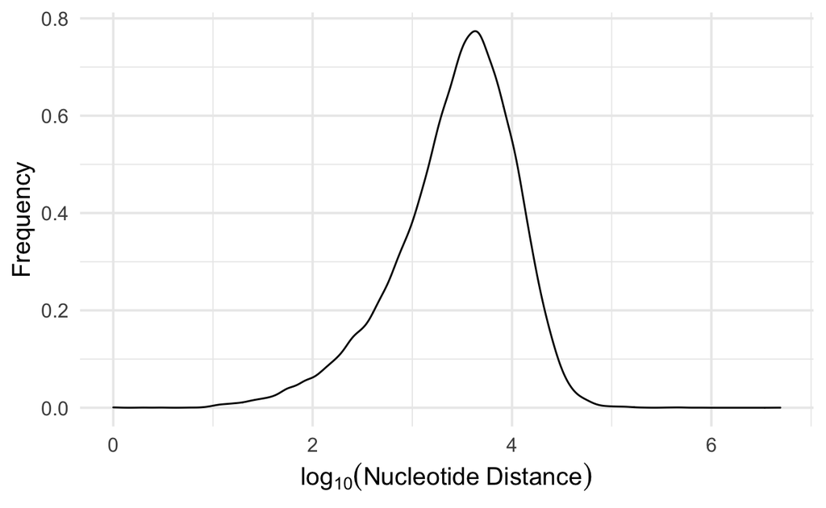

Figure 1: The distribution of nearest neighbor distances for individual SNPs along Chromosome 2

## Topological Similarity

*Node Centric Features*

- *Degree* The number of edges connected to a particular node in the network.
- *Node Betweenness* A measure of the relative number of the shortest paths in the network that contain each node.
- *Node Closeness* The relative distance of a node to all other nodes in the network.

*Edge Centric Features*

*Graph Features*

[output not shown]

## Assympototic Stability

*Random Markers*

Asymptotic convergence on topology from random SNP’s.

# Acknowledgements

Dyer, R. J. 2015. *Landscapes and Plant Population Genetics*. *Landscape Genetics: Concepts, Methods, Applications*. https://doi.org/10.1002/9781118525258.ch11.

Dyer, Rodney J, and John D Nason. 2004. “Population Graphs: The Graph Theoretic Shape of Genetic Structure.” *Molecular Ecology* 13: 1713–27. http://www.ncbi.nlm.nih.gov/pubmed/15189198.